# Problem set 4

Author

Kai Mao

# 1 Quarto

# 2 Problem 1 - Tidyverse

Install and load the package nycflights13.

```r
library(nycflights13)
library(tidyverse)
```

## 2.1 a.Generate a table

```r
# Calculate the mean and median departure delays for each airport
departure_delays <- flights %>%
  group_by(origin) %>%
  summarise(
    mean_departure_delay = mean(dep_delay, na.rm = TRUE),
    median_departure_delay = median(dep_delay, na.rm = TRUE),
    flights_count = n()
  ) %>%
  ungroup() %>%
  filter(flights_count >= 10) %>%
  arrange(desc(mean_departure_delay)) %>%
  left_join(airports, by = c("origin" = "faa")) %>%
  select(name, mean_departure_delay, median_departure_delay)

# Output
print(departure_delays)
```

```
# A tibble: 3 × 3
  name                mean_departure_delay median_departure_delay
  <chr>                              <dbl>                  <dbl>
1 Newark Liberty Intl                 15.1                     -1
2 John F Kennedy Intl                 12.1                     -1
3 La Guardia                          10.3                     -3
```

```r
# Calculate the mean and median arrival delays for each airport
arrival_delays <- flights %>%
  group_by(dest) %>%
  summarise(
    mean_arrival_delay = mean(arr_delay, na.rm = TRUE),
    median_arrival_delay = median(arr_delay, na.rm = TRUE),
    flights_count = n()
  ) %>%
  ungroup() %>%
  filter(flights_count >= 10) %>%
  arrange(desc(mean_arrival_delay)) %>%
  left_join(airports, by = c("dest" = "faa")) %>%
  select(name, mean_arrival_delay, median_arrival_delay)

# Output
print(arrival_delays)
```

```
# A tibble: 102 × 3
   name                          mean_arrival_delay median_arrival_delay
   <chr>                                      <dbl>                <dbl>
 1 Columbia Metropolitan                       41.8                   28
 2 Tulsa Intl                                  33.7                   14
 3 Will Rogers World                           30.6                   16
 4 Jackson Hole Airport                        28.1                   15
 5 Mc Ghee Tyson                               24.1                    2
 6 Dane Co Rgnl Truax Fld                      20.2                    1
 7 Richmond Intl                               20.1                    1
 8 Akron Canton Regional Airport               19.7                    3
 9 Des Moines Intl                             19.0                    0
10 Gerald R Ford Intl                          18.2                    1
# ℹ 92 more rows
```

## 2.2 b. How many flights did the aircraft model with the fastest average speed take?

```r
# Find the aircraft model with the fastest average speed
fastest_aircraft <- flights %>%
  left_join(planes, by = "tailnum") %>%
  group_by(model) %>%
  summarise(
    average_speed = mean(distance / air_time * 60, na.rm = TRUE),  # 转换成每小时英里
    flights_count = n()
  ) %>%
  arrange(desc(average_speed)) %>%
  slice(1) %>%
  select(model, average_speed, flights_count)

# Output
print(fastest_aircraft)
```

```
# A tibble: 1 × 3
  model   average_speed flights_count
  <chr>           <dbl>         <int>
1 777-222          483.             4
```

# 3 Problem 2 - get_temp()

## 3.1 Code

```r
#' Calculate the average temperature for a given month and year
#'
#' This function calculates the average temperature for a specified month and year.
#' Users can specify if the output should be in Celsius and can provide their own
#' function to compute the mean.
#'
#' @param month The month as a numeric (1-12) or as a full month name (e.g., "January").
#' @param year The year as a numeric value, specifically between 1997 and 2000 for the dataset used.
#' @param data The data frame containing temperature data with columns named 'temp', 'month_numeric', and 'year'.
#' @param celsius Logical, indicating whether to convert the temperature to Celsius. Default is FALSE.
#' @param average_fn The function to use for computing the average temperature. Default is \code{mean}.
#'
#' @return Numeric, the average temperature for the given month and year, in the specified unit.
#' @export
#'
#' @examples
#' get_temp("Apr", 1999, data = nnmaps, celsius = TRUE)

# load the library
library(tidyverse)

# Define the get_temp function
get_temp <- function(month, year, data, celsius = FALSE, average_fn = mean){
  tryCatch({
    # Normalize month input to numeric if it is a string
    if (month %>% is.character){
      month_name <- c("January", "February", "March", "April", "May", "June",
                    "July","August", "September", "October", "November", "December")
      month %>%
      match.arg(month_name) %>%
      '=='(month_name) %>%
      which -> month
      }
    # Validate the month input
    else if (month %>% is.numeric){
      if (!month %in% 1:12){
        stop("Month value is not 1 to 12.")
      }
    }
    else {
      stop("Month is not character or numeric.")
    }
    # Validate the year input
    if (year %>% is.numeric){
      if (year < 1997 | year > 2000){
        stop("Year value is not 1997 to 2000.")
      }
    }
    else {
      stop("Year is not numeric.")
    }
    # Ensure average_fn is a function
    if(!(average_fn %>% is.function)){
      stop("average_fn is not a function.")
    }

  # Process the data to calculate the average temperature
  result <- data %>%
    select(temp, month_numeric, year) %>%
    rename(data_year = year) %>%
    filter(data_year == year, month_numeric == month) %>%
    summarise(average_temperature = average_fn(temp), na.rm = TRUE) %>%
    mutate(average_temperature = if (celsius) (average_temperature - 32) * 5/9 else average_temperature) %>%
    pull(average_temperature)

  # Return the average temperature
  return(result)
  }, error = function(e) {
    warning(e$message)
    NA
  })
}
```

## 3.2 Prove code works by evaluating the following.

```r
nnmaps <- read.csv("C:\\Users\\Feixing\\Desktop\\stats 506\\data\\Problem Set 4\\chicago-nmmaps.csv")
get_temp("Apr", 1999, data = nnmaps)
```

```
[1] 49.8
```

```r
get_temp("Apr", 1999, data = nnmaps, celsius = TRUE)
```

```
[1] 9.888889
```

```r
get_temp(10, 1998, data = nnmaps, average_fn = median)
```

```
[1] 55
```

```r
get_temp(13, 1998, data = nnmaps)
```

```
[1] NA
```

```r
get_temp(2, 2005, data = nnmaps)
```

```
[1] NA
```

```r
get_temp("November", 1999, data =nnmaps, celsius = TRUE,
         average_fn = function(x) {
           x %>% sort -> x
           x[2:(length(x) - 1)] %>% mean %>% return
         })
```

```
[1] 7.301587
```

# 4 Problem 3 - Visualization

## 4.1 a. Is there a change in the sales price in USD over time?

### 4.1.1 Code

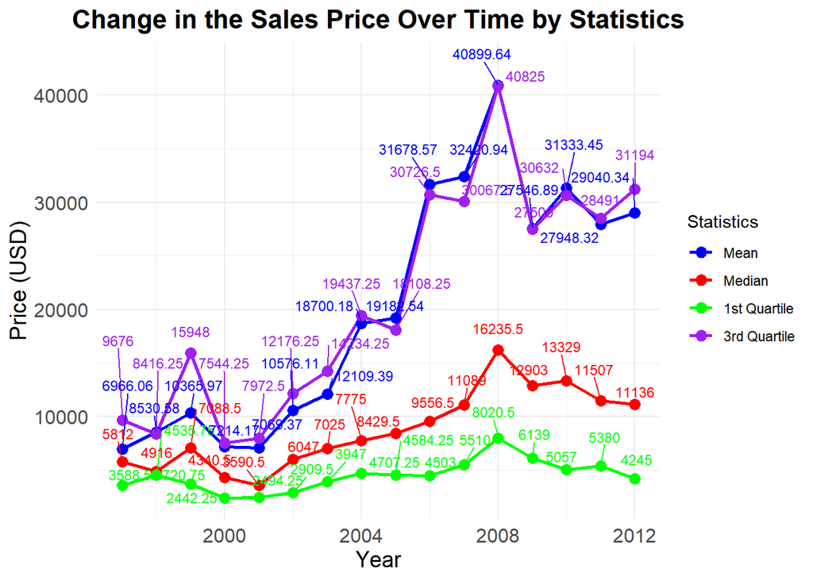

```r
# Load the necessary libraries
library(ggplot2)
library(dplyr)
library(ggrepel)  # For better label placement

# Load the data
art_sales <- read.csv("C:\\Users\\Feixing\\Desktop\\stats 506\\data\\Problem Set 4\\df_for_ml_improved_new_market.csv")

# Prepare the data for plotting
yearly_prices <- art_sales %>%
  group_by(year) %>%
  summarise(
    mean_price = mean(price_usd, na.rm = TRUE),
    median_price = median(price_usd, na.rm = TRUE),
    q1_price = quantile(price_usd, 0.25, na.rm = TRUE),
    q3_price = quantile(price_usd, 0.75, na.rm = TRUE)
  ) %>%
  pivot_longer(
    cols = c(mean_price, median_price, q1_price, q3_price),
    names_to = "statistic",
    values_to = "price"
  )

# Plot the data with enhanced visualization features
plot <- ggplot(yearly_prices, aes(x = year, y = price, color = statistic)) +
  geom_line(size = 1) +
  geom_point(size = 3) +
  geom_text_repel(
    aes(label = round(price, 2)),
    nudge_y = 2000,  # Adjust based on your data scale
    size = 3
  ) +
  labs(
    title = "Change in the Sales Price Over Time by Statistics",
    x = "Year",
    y = "Price (USD)",
    color = "Statistics"
  ) +
  theme_minimal() +
  theme(
    plot.title = element_text(hjust = 0.5, face = "bold", size = 16),
    axis.title = element_text(size = 14),
    axis.text = element_text(size = 12),
    plot.caption = element_text(hjust = 0, face = "italic"),
    legend.position = "right"
  ) +
  scale_color_manual(values = c("blue", "red", "green", "purple"),
                     labels = c("Mean", "Median", "1st Quartile", "3rd Quartile"),
                     name = "Statistics")
# Print the plot
print(plot)
```

### 4.1.2 Conclusion

Absolutely, there is a change in the sales price in USD over time.

The chart shows the trend of the sale price of art from 1997 to 2012. As can be clearly seen from the chart, selling prices have experienced significant fluctuations, especially between 2004 and 2008, when prices rose significantly and reached their peak. Prices have since fallen back, but the overall trend remains upward through 2012.